# Correlation

Author

Brier Gallihugh, M.S.

Published

March 17, 2023

## Introduction

Correlations might be the most common statistical test run (especially early on in a project). For this part of the workshop we will be using the `mtcars` data set due to its many numerical values that we can assess for correlation. Below we will see the first 10 rows of the data set displayed

```r
library(tidyverse)
library(car)
library(psych)

data <- mtcars

print(head(data,10))
```

**1**

Display the first 10 rows of the `mtcars` data. You can also return the last 10 rows with the following function `tail(data,10)`

```
                   mpg cyl  disp  hp drat    wt  qsec vs am gear carb
Mazda RX4         21.0   6 160.0 110 3.90 2.620 16.46  0  1    4    4
Mazda RX4 Wag     21.0   6 160.0 110 3.90 2.875 17.02  0  1    4    4
Datsun 710        22.8   4 108.0  93 3.85 2.320 18.61  1  1    4    1
Hornet 4 Drive    21.4   6 258.0 110 3.08 3.215 19.44  1  0    3    1
Hornet Sportabout 18.7   8 360.0 175 3.15 3.440 17.02  0  0    3    2
Valiant           18.1   6 225.0 105 2.76 3.460 20.22  1  0    3    1
Duster 360        14.3   8 360.0 245 3.21 3.570 15.84  0  0    3    4
Merc 240D         24.4   4 146.7  62 3.69 3.190 20.00  1  0    4    2
Merc 230          22.8   4 140.8  95 3.92 3.150 22.90  1  0    4    2
Merc 280          19.2   6 167.6 123 3.92 3.440 18.30  1  0    4    4
```

## Statistical Assumptions

The primary assumption of a **Pearson’s correlation coefficient** is that the data is on some kind of interval scale. However, if we wish to generalize, we must have a random large sample (unlikely) and the individual variables should be roughly normally distributed. This is the assumption we will focus on for this part of the workshop.

### Normality of Variables

For this part of the workshop, we are going to focus on the `mpg` and `wt` variables. We will be looking at normality both statistically<sub>1</sub> as well as graphically.

**A Note About Statistical Assumption Testing**

1. Odds are your statistical test is going to fail pretty much every single time. Particularly if you use something like a Shapiro Wilk test, but we’ll look at it anyway

#### Graphical Depiction of Normality Assumption (mpg)

```r
mpg_plot <- ggplot(data,aes(x = mpg)) +
  geom_histogram(aes(y=after_stat(density))) +
  stat_function(fun = dnorm,
                args = list(mean = mean(data$mpg),
                            sd = sd(data$mpg)),
                col = "blue") +
  theme_classic()

print(mpg_plot)
```

**1**

This should look very familiar to the histogram part of the workshop

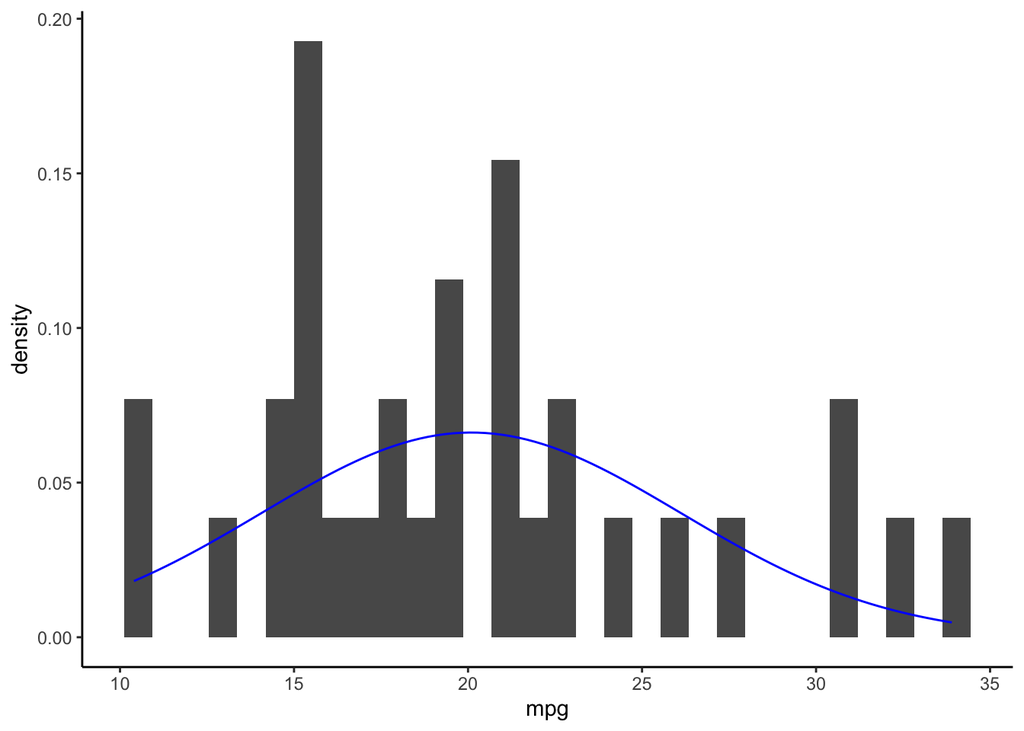

#### Statistical Depiction of Normality Assumption (mpg)

```r
print(psych::describe(data$mpg))

print(shapiro.test(data$mpg))
```

**1**

The `psych` package has a bunch of nifty functions for social science research. One is the `describe()` function which gives you a bunch of variable level summary statistics (e.g., mean, median, se, etc.)

**2**

The `shapiro.test()` performs a Shapiro Wilk test of normality. Keep in mind this particular test is very sensitive to sample sizes

```
   vars  n  mean   sd median trimmed  mad  min  max range skew kurtosis   se
X1    1 32 20.09 6.03   19.2    19.7 5.41 10.4 33.9  23.5 0.61    -0.37 1.07

    Shapiro-Wilk normality test

data:  data$mpg
W = 0.94756, p-value = 0.1229
```

#### Graphical Depiction of Normality Assumption (wt)

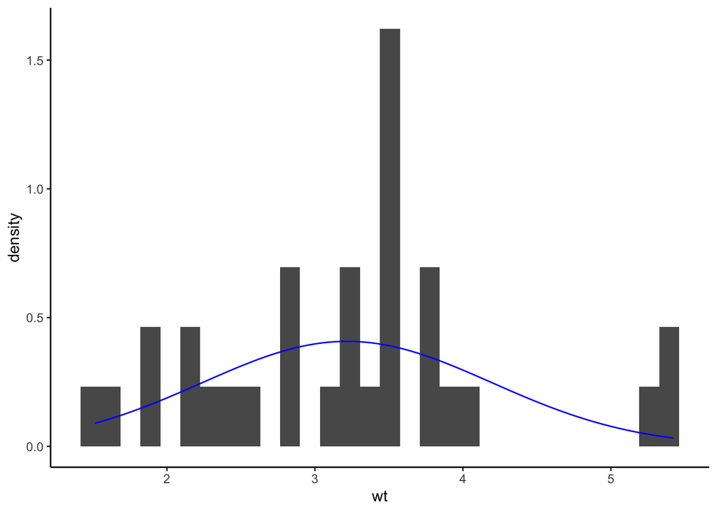

```r
wt_plot <- ggplot(data,aes(x = wt)) +
  geom_histogram(aes(y=after_stat(density))) +
  stat_function(fun = dnorm,
                args = list(mean = mean(data$wt),
                            sd = sd(data$wt)),
                col = "blue") +
  theme_classic()

print(wt_plot)
```

#### Statistical Depiction of Normality Assumption (wt)

```r
print(psych::describe(data$wt))
print(shapiro.test(data$wt))
```

```
   vars  n mean   sd median trimmed  mad  min  max range skew kurtosis   se
X1    1 32 3.22 0.98   3.33    3.15 0.77 1.51 5.42  3.91 0.42    -0.02 0.17
```

```
    Shapiro-Wilk normality test

data:  data$wt
W = 0.94326, p-value = 0.09265
```

## Running An Actual Correlation

There are multiple packages and methods for calculating a correlation in R depending on what you want to assess. The best to use for psychology is probably the `corr.test()` function in the `psych` package because it allows you to change the type of correlation you wish to compute (e.g., spearman vs pearson) as well as generate confidence intervals and do p value adjustments

```r
corr_results <- corr.test(x = data$mpg,
          y = data$wt,
          use = "pairwise",
          method = "pearson",
          adjust = "holm")

?corr.test()
```

**1**

Choose one of your variables to be your `x` variable

**2**

Choose the other to be your `y` variable

**3**

You can choose “pairwise” or “complete”. For information on what each does, use the following function to access the documentation: `?psych::corr.test()`

**4**

You can adjust method to be other ones like “spearman”

**5**

You can also use “bonferroni” among a few others

Below we will see the output of the correlation results as you might be used to seeing in a program like SPSS.

```r
print(corr_results)
```

```
Call:corr.test(x = data$mpg, y = data$wt, use = "pairwise", method = "pearson",
    adjust = "holm")
Correlation matrix
[1] -0.87
Sample Size
[1] 32
These are the unadjusted probability values.
  The probability values  adjusted for multiple tests are in the p.adj object.
[1] 0

 To see confidence intervals of the correlations, print with the short=FALSE option
```

$r$ = -.87 , $p$ < .001 with a CI = [-.93,-.74]

```r
print(corr_results$ci)
```

```
           lower          r      upper            p
NA-NA -0.9338264 -0.8676594 -0.7440872 1.293959e-10
```